# Assignment 2, Part B

Carter Fitzgerald

2023-10-14

# Part B - Data Wrangling (33 marks)

**Perform the following tasks**

1. 1. Load the `act_weather_data_partA.csv` into a data frame or a tibble, named, `act_weather_data`. (1 mark)

```r
library(tidyverse)
```

```r
library(dplyr)
library(Metrics)
library(modeest)
library(lubridate)
library(ggplot2)
library(gridExtra)
act_weather_data <- read_csv("act_weather_data_partA.csv")
```

2. Print the summary including the (minimum, median, mean, maximum) of each of the following variables: (5 marks)
- `Minimum_temperature`,
- `Maximum_temperature`,
- `9am_Temperature`,
- `Speed_of_maximum_wind_gust_(km/h)`, and
- `3pm_Temperature`

```r
summary(act_weather_data$Minimum_temperature)
```

```
##    Min. 1st Qu.  Median    Mean 3rd Qu.    Max.
##  -6.500   2.500   7.400   7.353  12.200  26.700
```

```r
summary(act_weather_data$Maximum_temperature)
```

```
##    Min. 1st Qu.  Median    Mean 3rd Qu.    Max.
##    6.30   15.22   20.70   21.15   26.10   44.00
```

```r
summary(act_weather_data$'9am_Temperature')
```

```
##    Min. 1st Qu.  Median    Mean 3rd Qu.    Max.
##   -0.80    8.80   13.50   13.13   17.30   34.50
```

```r
summary(act_weather_data$'Speed_of_maximum_wind_gust_(km/h)')
```

```
##    Min. 1st Qu.  Median    Mean 3rd Qu.    Max.
##   13.00   33.00   41.00   41.72   50.00  117.00
```

```r
summary(act_weather_data$'3pm_Temperature')
```

```
##    Min. 1st Qu.  Median    Mean 3rd Qu.    Max.
##    4.70   13.90   19.10   19.62   24.50   42.30
```

3. Based on the minimum and maximum temperature columns, compute the average temperature per month. Please note that we have 52 months provided in the data, so there will be 52 generated values. (4 marks)

```r
act_weather_data$Date <- as.Date(act_weather_data$Date, format = "%d/%m/%Y")

# Calculate daily average temperature
monthly_avg_temperature <- act_weather_data %>%
  mutate(Year = year(Date), Month = month(Date)) %>%
  group_by(Year, Month) %>%
  summarise(Avg_Monthly_Temperature = mean((Maximum_temperature + Minimum_temperature) / 2))
monthly_avg_temperature
```

```
## # A tibble: 52 × 3
## # Groups:   Year [6]
##     Year Month Avg_Monthly_Temperature
##    <dbl> <dbl>                   <dbl>
##  1  2018     8                    7.32
##  2  2018     9                    9.89
##  3  2018    10                   15.0
##  4  2018    11                   17.5
##  5  2018    12                   21.5
##  6  2019     1                   26.1
##  7  2019     2                   21.0
##  8  2019     3                   19.0
##  9  2019     4                   15.0
## 10  2019     5                    9.96
## # ℹ 42 more rows
```

4. What is the average speed of maximum wind gust for each group of the direction of maximum wind gust? (2 marks)

```r
# Group the data by the direction of maximum wind gust and calculate the average speed
wind_data <- act_weather_data %>%
  group_by(Direction_of_maximum_wind_gust) %>%
  summarise(Avg_Speed_of_maximum_wind_gust = mean(`Speed_of_maximum_wind_gust_(km/h)`, na.rm = TRUE))

print(wind_data)
```

```
## # A tibble: 16 × 2
##    Direction_of_maximum_wind_gust Avg_Speed_of_maximum_wind_gust
##    <chr>                                                   <dbl>
##  1 E                                                        39.2
##  2 ENE                                                      37.1
##  3 ESE                                                      39.1
##  4 N                                                        35.7
##  5 NE                                                       33.7
##  6 NNE                                                      30.4
##  7 NNW                                                      42.4
##  8 NW                                                       46.5
##  9 S                                                        44.5
## 10 SE                                                       36
## 11 SSE                                                      40.2
## 12 SSW                                                      40.5
## 13 SW                                                       44.5
## 14 W                                                        45.4
## 15 WNW                                                      48.5
## 16 WSW                                                      40.6
```

5. Which month has the highest average rain fall? And in which year? (2 marks)
- ( *hint:* in this question you may use group_by, summarise and which.max functions)

```r
# Calculate the average rainfall
rain_data <- act_weather_data %>%
  group_by(Year, Month) %>%
  summarize(Avg_Rainfall = mean(`Rainfall_(mm)`, na.rm = TRUE))
# Find row with the highest average rainfall
max_rainfall_row <- rain_data[which.max(rain_data$Avg_Rainfall), ]

# Get Year and Month with the highest average rainfall
highest_rainfall_year <- max_rainfall_row$Year
highest_rainfall_month <- max_rainfall_row$Month

cat("The month with the highest average rainfall is in Year:", highest_rainfall_year, "Month:", highest_rainfall_month)
```

```
## The month with the highest average rainfall is in Year: 2022 Month: 10
```

6. Which month was the driest in average, ( *i.e.*, least amount of rainfall in average)? And in which year? (3 marks)

```r
# Calculate the average rainfall
result <- act_weather_data %>%
  group_by(Year, Month) %>%
  summarize(Avg_Rainfall = mean(`Rainfall_(mm)`, na.rm = TRUE))
# Find row with the lowest average rainfall
min_rainfall_row <- result[which.min(result$Avg_Rainfall), ]

# Get Year and Month with the lowest average rainfall
driest_month_year <- min_rainfall_row$Year
driest_month <- min_rainfall_row$Month

cat("The driest month in terms of average rainfall is in Year:", driest_month_year, "Month:", driest_month)
```

```
## The driest month in terms of average rainfall is in Year: 2019 Month: 12
```

7. For the humidity, which month was receiving highest humidity level, in average, in the 2019 year? (3 marks)

```r
# Filter the data for the year 2019
data_2019 <- act_weather_data %>% filter(Year == 2019)

# Calculate the average of 9am and 3pm humidity
result <- data_2019 %>%
  group_by(Month) %>%
  summarize(Avg_Humidity = mean(c(`9am_relative_humidity_(%)`, `3pm_relative_humidity_(%)`), na.rm = TRUE))

# Find= row with the highest average combined humidity
max_humidity_row <- result[which.max(result$Avg_Humidity), ]

# Get Month with the highest average combined humidity
highest_humidity_month <- max_humidity_row$Month

cat("The month in 2019 with the highest average combined humidity level (9am and 3pm) is Month:", highest_humidity_month)
```

```
## The month in 2019 with the highest average combined humidity level (9am and 3pm) is Month: 6
```

8. For the period between August 2020 and July 2021 inclusive, Can you generate a summary table showing the minimum, maximum and average temperature (please use the `3 pm temperature` column), wind speed and humidity for each month and each quarter in the year? (5 marks)

```r
# Filter the data for the period between August 2020 and July 2021
data_aug2020_jul2021 <- act_weather_data %>%
  filter(Year == 2020 & Month >= 8 | Year == 2021 & Month <= 7)

# Group the filtered data by Year, Quarter, and Month, and calculate the statistics
summary_table <- data_aug2020_jul2021 %>%
  group_by(Year, Quarter = cut(Month, breaks = c(0, 3, 6, 9, 12), labels = c("Q1", "Q2", "Q3", "Q4")), Month) %>%
  summarise(
    Min_Temp = min(`3pm_Temperature`, na.rm = TRUE),
    Max_Temp = max(`3pm_Temperature`, na.rm = TRUE),
    Avg_Temp = mean(`3pm_Temperature`, na.rm = TRUE),
    Min_WindS = min(`3pm_wind_speed_(km/h)`, na.rm = TRUE),
    Max_WindS = max(`3pm_wind_speed_(km/h)`, na.rm = TRUE),
    Avg_WindS = mean(`3pm_wind_speed_(km/h)`, na.rm = TRUE),
    Min_Hum = min(`3pm_relative_humidity_(%)`, na.rm = TRUE),
    Max_Hum = max(`3pm_relative_humidity_(%)`, na.rm = TRUE),
    Avg_Hum = mean(`3pm_relative_humidity_(%)`, na.rm = TRUE)
  )
# Combine each quarter's data together
quarterly_summary_table <- summary_table %>%
  group_by(Year, Quarter) %>%
  summarize(
    Min_Temperature = min(Min_Temp),
    Max_Temperature = max(Max_Temp),
    Avg_Temperature = mean(Avg_Temp),
    Min_Wind_Speed = min(Min_WindS),
    Max_Wind_Speed = max(Max_WindS),
    Avg_Wind_Speed = mean(Avg_WindS),
    Min_Humidity = min(Min_Hum),
    Max_Humidity = max(Max_Hum),
    Avg_Humidity = mean(Avg_Hum)
  )
quarterly_summary_table
```

```
## # A tibble: 5 × 11
## # Groups:   Year [2]
##    Year Quarter Min_Temperature Max_Temperature Avg_Temperature Min_Wind_Speed
##   <dbl> <fct>             <dbl>           <dbl>           <dbl>          <dbl>
## 1  2020 Q3                  5.7            23.1            13.9              0
## 2  2020 Q4                  9.1            34.2            22.2              0
## 3  2021 Q1                 13.6            36.2            23.9              0
## 4  2021 Q2                  8              27.6            15.6              0
## 5  2021 Q3                  5.8            14.6            10.3              0
## # ℹ 5 more variables: Max_Wind_Speed <dbl>, Avg_Wind_Speed <dbl>,
## #   Min_Humidity <dbl>, Max_Humidity <dbl>, Avg_Humidity <dbl>
```

```r
summary_table
```

```
## # A tibble: 12 × 12
## # Groups:   Year, Quarter [5]
##     Year Quarter Month Min_Temp Max_Temp Avg_Temp Min_WindS Max_WindS Avg_WindS
##    <dbl> <fct>   <dbl>    <dbl>    <dbl>    <dbl>     <dbl>     <dbl>     <dbl>
##  1  2020 Q3          8      5.9     17.9     11.4         0        37      22.4
##  2  2020 Q3          9      5.7     23.1     16.3         9        35      22.7
##  3  2020 Q4         10     11.3     26       19.0         0        35      20.5
##  4  2020 Q4         11      9.1     34.2     23.6         9        46      21.8
##  5  2020 Q4         12     18.4     32.1     23.8         7        44      22.6
##  6  2021 Q1          1     15       36.2     26.0         0        39      20.5
##  7  2021 Q1          2     18.5     29.4     24.2         7        35      17.7
##  8  2021 Q1          3     13.6     28.4     21.5         7        35      17.6
##  9  2021 Q2          4     13.1     27.6     19.8         4        31      16.8
## 10  2021 Q2          5     10.7     21.4     15.2         6        35      18.8
## 11  2021 Q2          6      8       16.8     11.7         0        33      17.8
## 12  2021 Q3          7      5.8     14.6     10.3         0        37      20.5
## # ℹ 3 more variables: Min_Hum <dbl>, Max_Hum <dbl>, Avg_Hum <dbl>
```

9. Build graph(s) that show the distribution of the variables in the question #8. (5 marks)
- ( *hint:* There will be six graphs where each of them include distributions of minimum, maximum and average of variables temperature, wind speed or humidity per month and quarter.

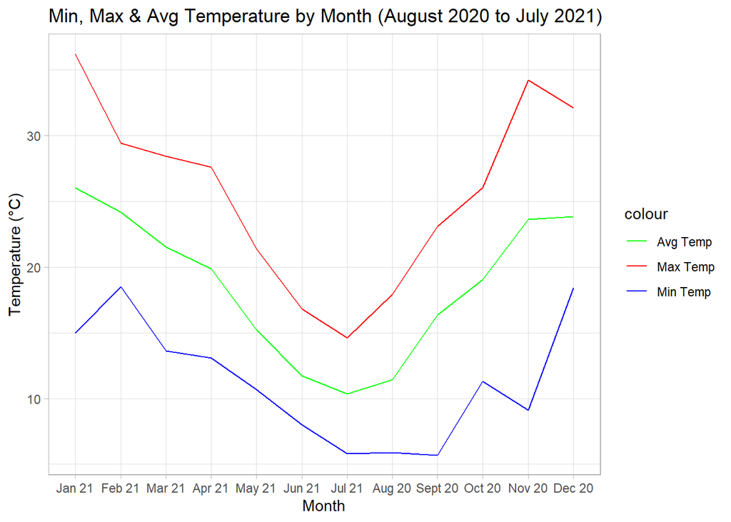

```r
monthly_summary_table <- summary_table %>%
  filter(!is.na(Month))

month_order <- c("Jan 21", "Feb 21", "Mar 21", "Apr 21", "May 21", "Jun 21", "Jul 21", "Aug 20", "Sept 20", "Oct 20", "Nov 20", "Dec 20")

# Creates Line graph for temperature
temperature_monthly <- ggplot(monthly_summary_table, aes(x = Month)) +
  geom_line(aes(y = Max_Temp, color = "Max Temp")) +
  geom_line(aes(y = Min_Temp, color = "Min Temp")) +
  geom_line(aes(y = Avg_Temp, color = "Avg Temp")) +
  labs(title = "Min, Max & Avg Temperature by Month (August 2020 to July 2021)",
       x = "Month",
       y = "Temperature (°C)") +
  scale_color_manual(values = c("Max Temp" = "red", "Min Temp" = "blue", "Avg Temp" = "green")) +
  scale_x_discrete(limits = month_order) +
  theme_light()

# Creates Line graph for Humidity
humidity_monthly <- ggplot(monthly_summary_table, aes(x = Month)) +
  geom_line(aes(y = Max_Hum, color = "Max Humidity")) +
  geom_line(aes(y = Min_Hum, color = "Min Humidity")) +
  geom_line(aes(y = Avg_Hum, color = "Avg Humidity")) +
  labs(title = "Min, Max & Avg Humidity by Month (August 2020 to July 2021)",
       x = "Month",
       y = "Humidity (%)") +
  scale_color_manual(values = c("Max Humidity" = "red", "Min Humidity" = "blue", "Avg Humidity" = "green")) +
  scale_x_discrete(limits = month_order) +
  theme_light()

# Creates Line graph for Wind Speed
wind_speed_monthly <- ggplot(monthly_summary_table, aes(x = Month)) +
  geom_line(aes(y = Max_WindS, color = "Max Wind Speed")) +
  geom_line(aes(y = Min_WindS, color = "Min Wind Speed")) +
  geom_line(aes(y = Avg_WindS, color = "Avg Wind Speed")) +
  labs(title = "Min, Max & Avg Wind Speed by Month (August 2020 to July 2021)",
       x = "Month",
       y = "Wind Speed (km/h)") +
  scale_color_manual(values = c("Max Wind Speed" = "red", "Min Wind Speed" = "blue", "Avg Wind Speed" = "green")) +
  scale_x_discrete(limits = month_order) +
  theme_light()

# Filter the data for quarters
quarterly_temperature_summary_table <- summary_table %>%
  filter(!is.na(Quarter))

temperature_quarterly_box_data <- quarterly_summary_table %>%
  pivot_longer(cols = starts_with("Min_Temperature"), names_to = "Statistic", values_to = "Temperature")

# Creates Line graph for temperature (Quarterly)
temperature_quarterly_line <- ggplot(quarterly_summary_table, aes(x = Quarter, group = 1)) +
  geom_line(aes(y = Min_Temperature, color = "Min Temp")) +
  geom_line(aes(y = Max_Temperature, color = "Max Temp")) +
  geom_line(aes(y = Avg_Temperature, color = "Avg Temp")) +
  labs(title = "Min, Max & Avg Temperature by Quarter (August 2020 to July 2021)",
       x = "Quarter",
       y = "Temperature (°C)") +
  scale_color_manual(values = c("Max Temp" = "red", "Min Temp" = "blue", "Avg Temp" = "green")) +
  theme_light()

# Creates Line graph for HUmidity (Quarterly)
humidity_quarterly_line <- ggplot(quarterly_summary_table, aes(x = Quarter, group = 1)) +
  geom_line(aes(y = Min_Humidity, color = "Min Humidity")) +
  geom_line(aes(y = Max_Humidity, color = "Max Humidity")) +
  geom_line(aes(y = Avg_Humidity, color = "Avg Humidity")) +
  labs(title = "Min, Max & Avg Humidity by Quarter (August 2020 to July 2021)",
       x = "Quarter",
       y = "Humidity (%)") +
  scale_color_manual(values = c("Max Humidity" = "red", "Min Humidity" = "blue", "Avg Humidity" = "green")) +
  theme_light()

# Creates Line graph for Wind Speed (Quarterly)
wind_speed_quarterly_line <- ggplot(quarterly_summary_table, aes(x = Quarter, group = 1)) +
  geom_line(aes(y = Min_Wind_Speed, color = "Min Wind Speed")) +
  geom_line(aes(y = Max_Wind_Speed, color = "Max Wind Speed")) +
  geom_line(aes(y = Avg_Wind_Speed, color = "Avg Wind Speed")) +
  labs(title = "Min, Max & Avg Wind Speed by Quarter (August 2020 to July 2021)",
       x = "Quarter",
       y = "Wind Speed (Km/h)") +
  scale_color_manual(values = c("Max Wind Speed" = "red", "Min Wind Speed" = "blue", "Avg Wind Speed" = "green")) +
  theme_light()

print(temperature_monthly)
```

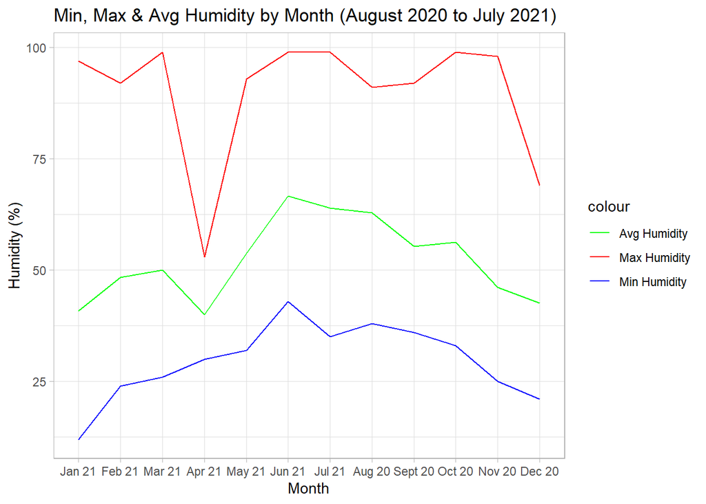

```r
print(humidity_monthly)
```

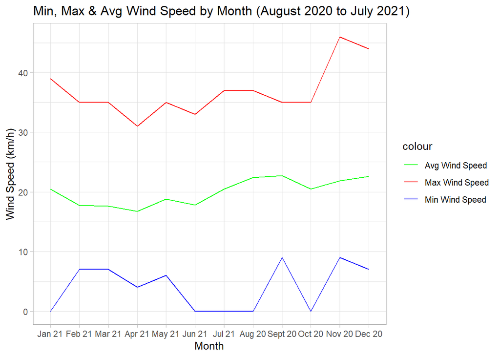

```r
print(wind_speed_monthly)
```

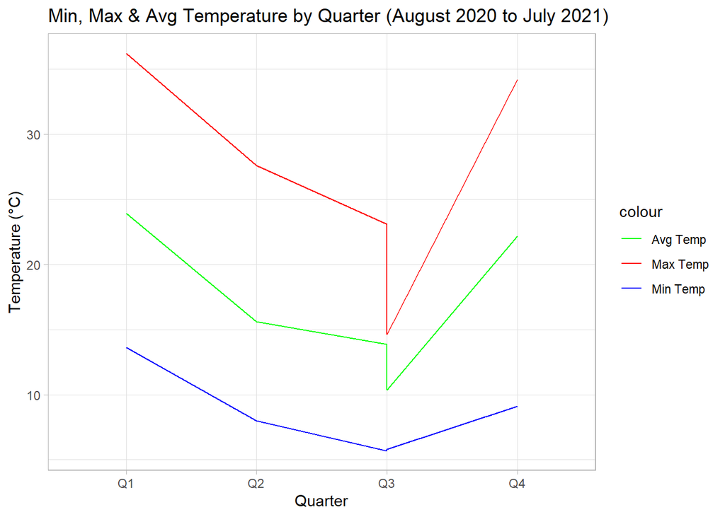

```r
print(temperature_quarterly_line)
```

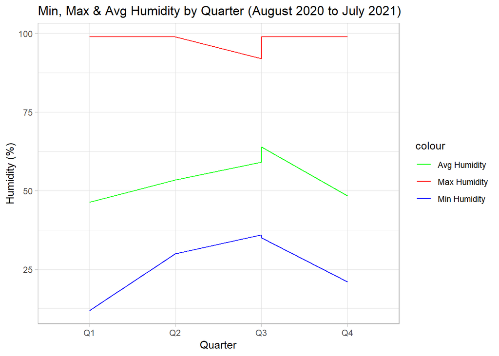

```r
print(humidity_quarterly_line)
```

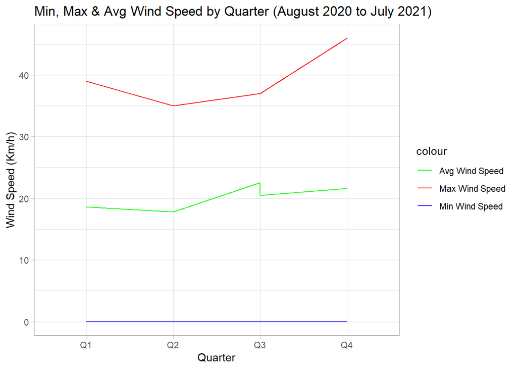

```r
print(wind_speed_quarterly_line)
```

10. Provide a narrative to describe your thoughts on the generated graphs from your answer of question #9 (3 marks)

**Description goes below**

For Question 9, I created a series of graphs to visualize the distribution of weather variables over the period from August 2020 to July 2021. These graphs can help us gain insights into the patterns and changes in temperature, wind speed, and humidity both on a monthly and quarterly basis. I created 6 graphs which all plot the maximum, minimum and average of there respective variable. I have 3 graphs for monthly each looks a different variable (Temp, Humidity & Wind Speed) and the other 3 are the same, except instead of monthly they are quarterly.

Personally, I think the monthly graphs, provide a greater understanding of the data and provide more useful data, due to the increased range of the graphs. It allows us to better analysis patterns and trends in the data. In comparison, the quarterly graphs are very simple and can give you an idea of the climate at a glance.